# Práctica Análisis Exploratorio R

Guillermo Bonafonte Criado

## 1. Introducción con el objetivo del análisis:

En este estudio se hará primeramente un análisis descriptivo de un dataset que consta de estudiantes de matemáticas y portugués así como un análisis exploratorio de los mismos. ¿Es posible predecir el rendimiento del estudiante? ¿Cuáles son los factores que afectan al éxito estudiantil?

## 2. Carga de datos

### Establecemos y obtenemos directorio de trabajo

Obtenemos directorio de trabajo y lo asignamos

```r
getwd()
```

```
## [1] "/Users/Guille/Desktop"
```

```r
setwd(getwd())
```

### Comprobar y crear directorio

Si no existiera el directorio lo creamos y descargamos los datasets Almacenamos tambien la fecha de descarga

```r
if (!file.exists("datos"))
{
  dir.create("datos")
  fileUrl <- "https://archive.ics.uci.edu/ml/machine-learning-databases/00320/student.zip"
  download.file(fileUrl,destfile="./datos/student.zip", method="curl")
  unzip("./datos/student.zip", exdir="./datos")
  list.files("./datos")
  rm(fileUrl)
  fechaDescarga <- date()
  fechaDescarga
}
```

### Cargamos los datos con read.table()

```r
library(knitr)
studentMat <- read.table("./datos/student-mat.csv",
                         row.names=NULL, sep=";", header=TRUE)
studentPor <- read.table("./datos/student-por.csv",
                         row.names=NULL, sep=";", header=TRUE)
```

Mostramos un parte de la estructura del datasets para hacernos una idea de su contenido

```r
kable(head(studentMat[,1:8]))
```

| school | sex | age | address | famsize | Pstatus | Medu | Fedu |
| --- | --- | --- | --- | --- | --- | --- | --- |
| GP | F | 18 | U | GT3 | A | 4 | 4 |
| GP | F | 17 | U | GT3 | T | 1 | 1 |
| GP | F | 15 | U | LE3 | T | 1 | 1 |
| GP | F | 15 | U | GT3 | T | 4 | 2 |
| GP | F | 16 | U | GT3 | T | 3 | 3 |
| GP | M | 16 | U | LE3 | T | 4 | 3 |

```r
kable(head(studentPor[,1:8]))
```

| school | sex | age | address | famsize | Pstatus | Medu | Fedu |
| --- | --- | --- | --- | --- | --- | --- | --- |
| GP | F | 18 | U | GT3 | A | 4 | 4 |
| GP | F | 17 | U | GT3 | T | 1 | 1 |
| GP | F | 15 | U | LE3 | T | 1 | 1 |
| GP | F | 15 | U | GT3 | T | 4 | 2 |
| GP | F | 16 | U | GT3 | T | 3 | 3 |
| GP | M | 16 | U | LE3 | T | 4 | 3 |

Posteriormente obtenemos los estudiantes que aparecen en ambos CSV y comprobamos el tamaño

```r
studentMerge <- merge(studentMat,studentPor,
                       by=c("school","sex","age",
                            "address","famsize",
                            "Pstatus","Medu",
                            "Fedu","Mjob",
                            "Fjob","reason",
                            "nursery","internet"),
                       all=FALSE,
                       suffixes=c("mat","por"))

print(nrow(studentMerge))
```

```
## [1] 382
```

## 3. Análisis descriptivo

En esta fase se realizará un análisis descriptivo para el dataset “studentMerge” en el que aparecen los estudiantes de ambas materias. Para ello se utilizaran técnicas como media, mediana, dispersion.

### Media

- (mean). Es la media aritmética (promedio) de los valores de una variable. Suma de los valores dividido por el tamaño muestral.

```r
mean( studentMerge$G3mat )
```

```
## [1] 10.38743
```

```r
mean( studentMerge$G3por )
```

```
## [1] 12.51571
```

```r
mean( studentMerge$age )
```

```
## [1] 16.58639
```

### Mediana

- (median). Es un valor que divide a las observaciones en dos grupos con el mismo número de individuos (percentil 50). Si el número de datos es par, se elige la media de los dos datos centrales.

```r
median( studentMerge$G3mat )
```

```
## [1] 11
```

```r
median( studentMerge$G3por )
```

```
## [1] 13
```

### Dispersión

```r
#Rango de edades
range( studentMerge$age)
```

```
## [1] 15 22
```

### Varianza

```r
#Varianza notas G3mat y G3por
var( studentMerge$G3por)
```

```
## [1] 8.675606
```

```r
var( studentMerge$G3mat)
```

```
## [1] 21.97024
```

### Desviación típica

```r
#Desviación típica G3mat y G3por
sd( studentMerge$G3por)
```

```
## [1] 2.945438
```

```r
sd( studentMerge$G3mat)
```

```
## [1] 4.687242
```

### Coeficiente de variación

```r
#Coeficiente de variacion G3mat y G3por
sd( studentMerge$G3por) / mean( studentMerge$G3por )
```

```
## [1] 0.2353393
```

```r
sd( studentMerge$G3mat) / mean( studentMerge$G3mat )
```

```
## [1] 0.4512415
```

## 4. Análisis exploratorio

### Algunos gráficos útiles

#### Densidad

- Graficos que muestran la densidad de mujeres y hombres en relacion a su edad

```r
#Cargamos las librerías necesarias
library(ggplot2)
library(datasets)
library(dplyr)
library(ggplot2)
library(gridExtra)
library(lattice)
```

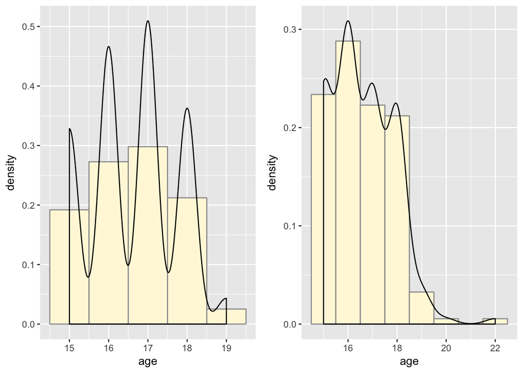

```r
# Density de mujeres en relacion a la edad
p1 <- ggplot(filter(studentMerge, sex=='F'), aes(x=age, y=..density..)) +
geom_histogram(fill="cornsilk", colour="grey60", binwidth=1 ) + geom_density()


# Density de hombres en relacion a la edad
p2 <- ggplot(filter(studentMerge, sex=='M'), aes(x=age, y=..density..)) +
geom_histogram(fill="cornsilk", colour="grey60", binwidth=1, ) +
    geom_density()

grid.arrange(p1, p2 , nrow=1)
```

#### Boxplot

- Boxplot que busca relacion notas y la razon por la que han elegido el colegio, tanto para las notas de portugués como para las de matemáticas

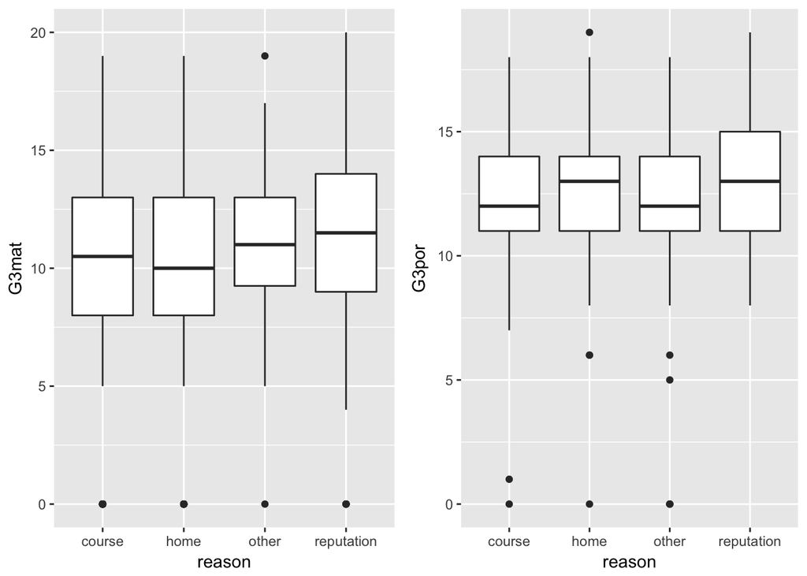

```r
plot1 <- qplot(reason, G3mat, data = studentMerge, geom = 'boxplot')
plot2 <- qplot(reason, G3por, data = studentMerge, geom = 'boxplot')
grid.arrange(plot1, plot2, nrow=1)
```

#### Violin

- Grafico de violin, que pinta las mismas relaciones que el boxplot anterior

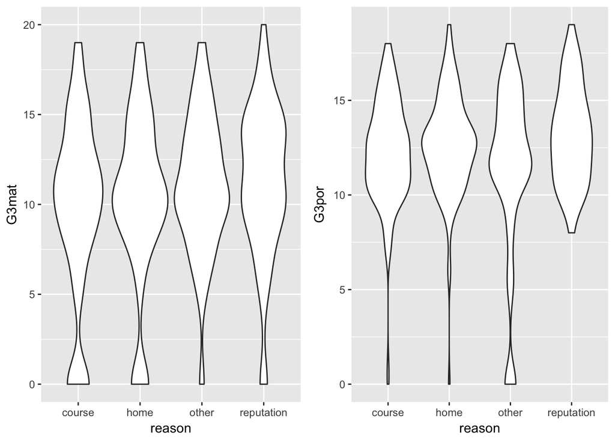

```r
plot1 <- qplot(reason, G3mat, data = studentMerge, geom = 'violin')
plot2 <- qplot(reason, G3por, data = studentMerge, geom = 'violin')
grid.arrange(plot1, plot2, nrow=1)
```

#### Clustering

- Para clasificar los datos, encontrar patrones…

```r
#Cargamos las librerías necesarias

  require(cluster)
  require(NbClust)
  require(factoextra)
```

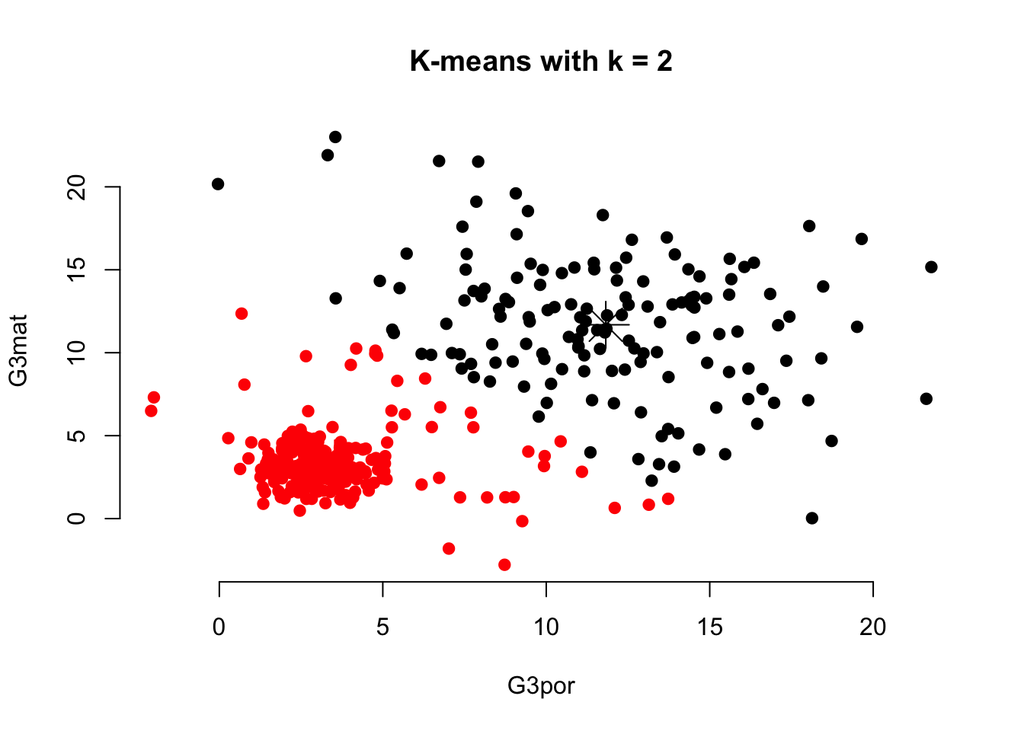

```r
  {
    set.seed(123)
    df <- rbind(matrix(rnorm(studentMerge$G3por, sd( studentMerge$G3por)), ncol = 2),
                matrix(rnorm(studentMerge$G3mat, mean( studentMerge$G3mat ), sd( studentMerge$G3mat)),ncol = 2))
    colnames(df) <- c("G3por", "G3mat")
    n_clusters <- 2
    km.res <- kmeans(df, n_clusters, nstart = 25)
    table(km.res$cluster)

    plot(df, col = km.res$cluster, pch = 19, frame = FALSE,main = "K-means with k = 2")
    points(km.res$centers, col = 1:2, pch = 8, cex = 3)
  }
```

## 5. Conclusiones

En principio el dataset es válido para predecir el rendimiento del estudiante. Algunos de los factores que vemos podrían ser claves en el éxito estudiantil podrían ser:

- Razon por la que han elegido la escuela, que podría mostrar mayor o menos predisposicion a los estudios
- Horas de estudio de una asignatura